# Annex

Author

Jordi Mas Elias

Published

October 9, 2024

# Unit of observation

The unit of observation of the dataset is the party-database, referred to a party registed in one of the three examined expert survey datasets that concurred to the national parliamentary elections in the years prior to 2019 and 2020. The V-Party v2 dataset (Lührmann et al. 2020), the Chapel Hill Expert Survey (CHES) v2019 dataset (Bakker et al. 2020) and the Global Party Survey (GPS) v1 dataset (Norris 2020) distributed the questionnaires between 2019 and 2020, although both V-Party and GPS have a time range of several decades back in time. In order to reduce the hindsight in the sample of parties (Levick and Olavarria-Gambi 2020), I limited the timeframe to January 2015. I also limited to one the number of times that a party-dataset observation may appear. In consequence, each party-dataset observation registers a political party that concurred in an national parliamentary election during the period 2015-2020.

As an example, the following Table 1 shows the party list in Portugal. Each party is comptabilized once per dataset, so for instance the Left Bloc and the Unified Democratic Coalition, that appear in the V-Party, the CHES and the GPS, appear three times. The Portuguese Communist Party was surveyed only in the CHES dataset, so it is comptabilized once.

Table 1: Base dataset

| iso3c | name_pf | id_db | db |
| --- | --- | --- | --- |
| PRT | Democratic and Social Center / People’s Party | 1202 | ches |
| PRT | Left Bloc | 1310 | vp |
| PRT | Left Bloc | 793 | gps |
| PRT | Left Bloc | 1208 | ches |
| PRT | Popular Democratic Party / Social Democratic Party | 1359 | vp |
| PRT | Popular Democratic Party / Social Democratic Party | 1206 | ches |
| PRT | Unified Democratic Coalition | 284 | vp |
| PRT | Unified Democratic Coalition | 792 | gps |
| PRT | Unified Democratic Coalition | 1201 | ches |
| PRT | Portuguese Communist Party | 1210 | ches |
| PRT | Socialist Party | 655 | vp |
| PRT | Socialist Party | 796 | gps |
| PRT | Socialist Party | 1205 | ches |
| PRT | People-Animals-Nature | 794 | gps |
| PRT | Portugal Ahead | 795 | gps |
| PRT | PAN | 1250 | ches |
| PRT | PEV | 1211 | ches |

The dataset totals 1.904 party-database observations from 168 different countries. It includes 837 party observations from the GPS dataset, 790 from the V-Party dataset, and 277 from the CHES dataset (because the CHES is focused in European parties).

- Shall I remove `independent` parties.
- Shall I remove `alliance:` parties.

| iso3c | country | gps | vp | ches | total |
| --- | --- | --- | --- | --- | --- |
| AFG | Afghanistan | 5 | 0 | 0 | 5 |
| AGO | Angola | 5 | 7 | 0 | 12 |
| ALB | Albania | 6 | 4 | 0 | 10 |
| ARE | United Arab Emirates | 0 | 2 | 0 | 2 |
| ARG | Argentina | 10 | 12 | 0 | 22 |
| ARM | Armenia | 3 | 10 | 0 | 13 |
| AUS | Australia | 8 | 4 | 0 | 12 |
| AUT | Austria | 6 | 5 | 5 | 16 |
| AZE | Azerbaijan | 2 | 1 | 0 | 3 |
| BDI | Burundi | 3 | 2 | 0 | 5 |
| BEL | Belgium | 0 | 10 | 11 | 21 |
| BEN | Benin | 10 | 18 | 0 | 28 |
| BFA | Burkina Faso | 0 | 1 | 0 | 1 |
| BGD | Bangladesh | 0 | 3 | 0 | 3 |
| BGR | Bulgaria | 5 | 8 | 10 | 23 |
| BHR | Bahrain | 3 | 0 | 0 | 3 |
| BHS | Bahamas | 3 | 0 | 0 | 3 |
| BIH | Bosnia & Herzegovina | 10 | 12 | 0 | 22 |
| BLR | Belarus | 6 | 4 | 0 | 10 |
| BLZ | Belize | 3 | 0 | 0 | 3 |
| BOL | Bolivia | 0 | 3 | 0 | 3 |
| BRA | Brazil | 8 | 8 | 0 | 16 |
| BRB | Barbados | 2 | 2 | 0 | 4 |
| BTN | Bhutan | 2 | 0 | 0 | 2 |
| BWA | Botswana | 0 | 3 | 0 | 3 |
| CAF | Central African Republic | 0 | 5 | 0 | 5 |
| CAN | Canada | 5 | 5 | 0 | 10 |
| CHE | Switzerland | 10 | 6 | 8 | 24 |
| CHL | Chile | 4 | 8 | 0 | 12 |
| CIV | Côte d’Ivoire | 5 | 2 | 0 | 7 |

[output cut: 138 more lines]

# Disagreement variable

The disagreement between coders is operationalized as the standard deviation of the scores given by the experts to a party in a particular question of a dataset. Using the logarithm of the standard deviation produces a more symmetric relationship but creates a spike in the observations on the lowest range (Figure 1). Moreover, it doesn’t enhance the explanatory power of the models.

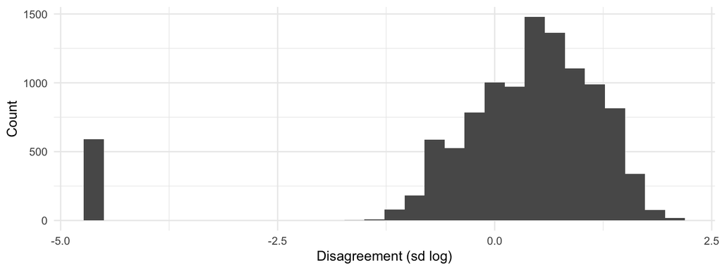

Figure 1: Disagreement between experts

When calculating the standard deviation, I also calculated two additional variables about the assessments: the number of experts that answered the particular item on the questionnaire (`na`) and the turnout, which is the result of dividing `na` per the number of experts that answered the questionnaire

I also calculated the variance, as a robustness test.

# Party size variable

The party size variable is operationalized as the percentage of votes received by the party in the national parliament. Since the analyzed expert surveys were conducted in 2019 or 2020, I prioritized the elections close to 2020 to adjust the expert assessment to the size of the party at the moment the evaluation takes place. The percentage of votes of each party is calculated in a several step procedure:

1. First, I prioritized the data already contained in the examined datasets. In particular, the *v2pavote* variable from the V-Party dataset and the *party_per_vote* variable from the GPS dataset include data about the percentage of votes of the registered parties.
2. Second, I transfered missing data from one dataset observation to another within the same party. For instance, the CHES dataset does not provide data from the percentage of votes to the political parties that it registers, but V-Party or GPS datasets have some identical observations. Therefore, following the example of Table 1, I could transfer data from the Socialist Party included in the V-Party dataset to the others. To do so, I connected the party observations through the ID codes from the PartyFacts database (Döring and Regel 2019). PartyFacts assigns a unique ID to each political party, by which makes easy to transfer information from one dataset to another. Thus, by utilizing PartyFacts ID codes, I was able to identify identical units of observation and impute data about the percentages of votes from one dataset to another.
3. Third, I also fill some data about the percentage of votes from the variable *pervote* from the Comparative Party Manifesto (CPM) v2022a dataset (Volkens et al. 2019), filtered from 2015 onwards (variable *edate*).
4. And fourth, when data about the percentage of votes was not available, I also imputed data about the percentage of seats gained by the party (variables *v2paseatshare* in the V-Party, *party_per_seats* in the GPS, and *absseat* & *totseats* in the CPM).

For the imputation procedures, I used a linear model imputation employing the percentage of votes or the percentage of seats as a predictive variable. Prior to imputation, I ensured that the correlation between variables (percentage of seats and percentage of votes) was larger than 0.60. In each dataset, the imputation went from higher correlation to lower correlation.

Through these procedures, I obtained data for 1.617 observations out of 1.904 (85%). The remaining 287 missing values were coded manually. In the manual coded, I used mainly two sources of information: the Party Facts web page, which in some occasions contained the percentage of votes of the party; and I consulted online other official and secondary sources of information.

Two methodological issues are worth mentioning. First, the GPS dataset sometimes provided the data in percentages and sometimes the data in one percent. So I had to adjust manually all the data to percentages. Second, some missing data were about parties belonging to coalitions. In that cases, I prioritized for the calculations: a) the percentage of votes received by the party; b) the percentage of seats received by the party; c) the percentage of seats or votes received by the party in a previous election, so as I could estimate the weight of the party in the coalition.

Ensuring that there were almost no missing data was important, since drawing conclusions from data it is problematic when NAs correlate with one the variable(s) of interest (called Missing-at-Random). In the case of this study, it was very likely that NAs were more present in small parties than in large parties, and also NAs were more present in parties from autocratic regimes than in parties from democratic regimes.

As Figure 2 shows, the percentage of votes data from the databases had a mean of 10. By contrast, with the manual coding I could access to data from smaller parties, mean 3. No observed different between democracies and autocracies.

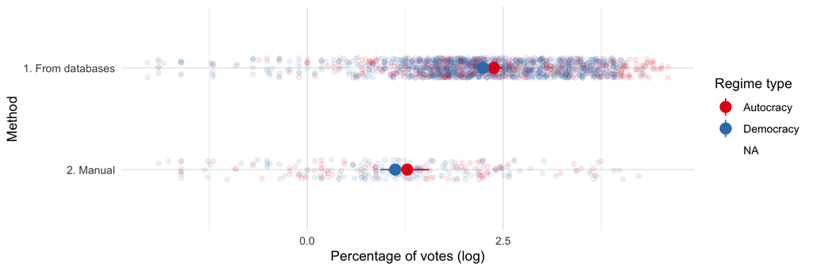

Figure 2: Imputation of the percentage of votes variable

Not all the observations have been filled with data. I left missing 41 party-dataset observations because I could not find any information about the percentage of votes received in a parliamentary election within the period 2015-2020.

Figure Figure 3 shows the imputed values across the *party size* and the *experts’ disagreement* variables. Each plot is faceted per dataset and dimension. Again, the missing data is concentrated in the lower range of the party size distribution.

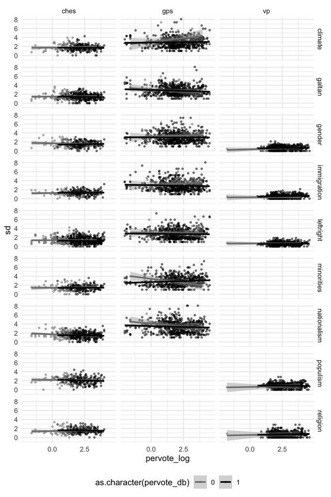

Figure 3: Imputation across standard deviation and percentage of votes

# Ideological dimensions

This section of the annex explains how the questions were grouped into ideological dimensions. The inclusion of question variables within dimensions follows both conceptual, empirical, and practical criteria.

Firstly, I qualitatively assessed the degree of conceptual similarity between variables. For example, the variables Redistribution and Spendvtax were provisionally included in the Left-Right dimension because these items are typically framed using left-right coordinates: more redistributive and pro-tax spending attitudes tend to be more left-wing oriented, whereas less redistributive and anti-tax spending attitudes tend to be more right-wing oriented. This qualitative assessment served as the initial allocation of variables within dimensions.

Secondly, for each dimension, I calculated the correlation between variables. I retained variables that were highly correlated with others and dropped those with poor correlation. A threshold of 0.60 was used to define strong correlations. Consequently, within each dimension, all variables have a minimum correlation coefficient of 0.60 with other variables.

Finally, a dimension must contain at least one variable from two different datasets.

Below, I provide a detailed explanation of each dimension. First, I define each variable, followed by the correlation matrix between the variables.

### Left-right dimension

The variables included in the left-right dimension are the following:

- `lrecon` (CHES): The variable ranges from Extreme left (0) to Extreme right (10).
- `lrgen` (CHES): The variable ranges from Extreme left (0) to Extreme right (10).
- `v2pariglef` (V-Party): The variable follows a Z-Scores standardization, ranging from Far-left (-5) to Far-right (5).
- `V4_Scale`: The variable ranges from Extreme economic left (0) to Extreme economic right (10).
- `redistribution` (CHES): The variable ranges from Strongly favors redistribution (0) to Strongly opposes redistribution (10).
- `spendvtax` (CHES): The variable ranges from Strongly favors improving public services (0) to Strongly favors reducing taxes (10).

|  | lrecon | lrgen | v2pariglef | V4_Scale | redistribution | spendvtax |
| --- | --- | --- | --- | --- | --- | --- |
| lrecon | 1.00 | 0.84 | 0.92 | 0.93 | 0.95 | 0.93 |
| lrgen | 0.84 | 1.00 | 0.88 | 0.78 | 0.80 | 0.81 |
| v2pariglef | 0.92 | 0.88 | 1.00 | 0.68 | 0.88 | 0.89 |
| V4_Scale | 0.93 | 0.78 | 0.68 | 1.00 | 0.88 | 0.87 |
| redistribution | 0.95 | 0.80 | 0.88 | 0.88 | 1.00 | 0.94 |
| spendvtax | 0.93 | 0.81 | 0.89 | 0.87 | 0.94 | 1.00 |

### GALTAN dimension

The variables included in the GALTAN dimension are the following:

- `galtan` (CHES): The variable ranges from Libertarian/Postmaterialist values (0) to Traditional/Authoritarian values (10).
- `V6_Scale` (GPS): The variable ranges from Very liberal (0) to Very conservative (10).
- `civlib_laworder` (CHES): The variable ranges from Strongly favors civil liberties (0) to strongly favors tough measures to fight crime (10).

|  | galtan | V6_Scale | civlib_laworder |
| --- | --- | --- | --- |
| galtan | 1.00 | 0.95 | 0.92 |
| V6_Scale | 0.95 | 1.00 | 0.87 |
| civlib_laworder | 0.92 | 0.87 | 1.00 |

### Gender dimension

|  | sociallifestyle | v2palgbt | V14 |
| --- | --- | --- | --- |
| sociallifestyle | 1.00 | 0.91 | 0.89 |
| v2palgbt | 0.91 | 1.00 | 0.62 |
| V14 | 0.89 | 0.62 | 1.00 |

### Nationalism dimension

The variables included in the nationalism dimension are the following:

- `nationalism` (CHES): The variable ranges from Strongly promotes cosmopolitan conceptions of society (0) to Strongly promotes nationalist conceptions of society (10).
- `multiculturalism` (CHES): The variable ranges from Strongly favors multiculturalism (0) to Strongly favors assimilation (10).
- `V13` (GPS): The variable scale has been inverted from the original source and ranges from Strongly favors multilateralism (0) to Strongly favors nationalism (10).

|  | nationalism | multiculturalism | V13 |
| --- | --- | --- | --- |
| nationalism | 1.00 | 0.92 | 0.84 |
| multiculturalism | 0.92 | 1.00 | 0.76 |
| V13 | 0.84 | 0.76 | 1.00 |

### Climate change dimension

The variables included in the climate change dimension are the following:

- `V12` (GPS): The variable ranges from Strongly favors environmental protection (0) to Strongly opposes environmental protection (10).
- `environment` (CHES): The variable ranges from Strongly supports environmental protection even at the cost of economic growth (0) to Strongly supports economic growth even at the cost of environmental protection (10).

|  | V12 | environment |
| --- | --- | --- |
| V12 | 1.00 | 0.89 |
| environment | 0.89 | 1.00 |

### Immigration dimension

The variables included in the immigration dimension are the following:

- `immigrate_policy` (CHES): The variable ranges from Strongly favors a liberal policy on immigration (0) to Strongly favors a restrictive policy on immigration (10).
- `v2paimmig` (V-Party): The variable scale has been inverted from its initial values and follows a Z-Scores standardization, ranging from from Strongly supports all or almost all forms of immigration into the country (-5) to Strongly opposes all or almost all forms of immigration into the country (5).
- `V10` (GPS): The variable ranges from Strongly favors liberal immigration policies (0) to Strongly favors restrictive immigration policies (10).

|  | immigrate_policy | v2paimmig | V10 |
| --- | --- | --- | --- |
| immigrate_policy | 1.00 | 0.93 | 0.95 |
| v2paimmig | 0.93 | 1.00 | 0.63 |
| V10 | 0.95 | 0.63 | 1.00 |

### Religion dimension

The variables included in the religion dimension are the following:

- `v2parelig` (V-Party): The variable scale has been inverted from the original source and ranges from Never invokes God, religion, or sacred/religious texts to justify its positions (-5) to Almost always invokes God, religion, or sacred/religious texts to justify its positions (5).
- `religious_principles` (CHES): The variable ranges from Strongly opposes religious principles in politics (0) to Strongly supports religious principles in politics (10).

|  | v2parelig | religious_principles |
| --- | --- | --- |
| v2parelig | 1.00 | 0.77 |
| religious_principles | 0.77 | 1.00 |

### Ethnic minorities dimension

The variables included in the ethnic minorities dimension are the following:

- `V15` (GPS): The variable ranges from Strongly favors ethnic minority rights (0) to Strongly opposes ethnic minority rights (10).
- `ethnic_minorities` (CHES): The variable ranges from Strongly favors more rights for ethnic minorities (0) to Strongly opposes more rights for ethnic minorities (10).

|  | V15 | ethnic_minorities |
| --- | --- | --- |
| V15 | 1.00 | 0.91 |
| ethnic_minorities | 0.91 | 1.00 |

### Corruption dimension

The variables included in the corruption dimension are the following:

- `v2paanteli` (V-Party): The variable ranges from The leadership of this party never makes statements against the elite (-5) to The leadership of this party makes statements against the elite whenever possible (5).
- `antielite_salience` (CHES): The variable ranges from Anti-establishment and anti-elite rhetoric not important at all (0) to Anti-establishment and anti-elite rhetoric extremely important (10).

|  | v2paanteli | antielite_salience |
| --- | --- | --- |
| v2paanteli | 1.00 | 0.88 |
| antielite_salience | 0.88 | 1.00 |

# Non State-wide Parties

Definition: Represents the interest of a regionally concentrated minority.

- Includes parties with reserved seats (Serbian List) and,
- Parties that are not presented in all the districts.

As main sources, I have followed the Regionalist parties dataset (Massetti and Schakel 2021) and the categorizations from Parties and Elections in Europe (Nordsieck 2019). I have also complemented the search with data from the three party databases I have used for the study. In particular, I looked at the variables `v2pagroup_5` and `v2pagroup_12` from the V-Party v2 dataset, which identify regional and ethnic parties. From the GPS v2020 dataset, I have used the variable `CHES_family` (the category 9 refers to regional parties). From the CHES v2019 dataset I have used the variable `regions`. And from the CPM 2022a dataset I have used the variable `parfam` (Ethnic and regional parties are registered in the value 90).

https://en.wikipedia.org/wiki/List_of_regional_and_minority_parties_in_Europe

[output not shown]

## References

Bakker, Ryan, Liesbet Hooghe, Seth Jolly, Gary Marks, Jonathan Polk, Jan Rovny, Marco Steenbergen, and Milada Anna Vachudova. 2020. “2019 Chapel Hill Expert Survey.” Chapel Hill, NC: University of North Carolina, Chapel Hill.

Döring, Holger, and Sven Regel. 2019. “Party Facts: A database of political parties worldwide.” *Party Politics*, 1–13.

Levick, Laura, and Mauricio Olavarria-Gambi. 2020. “Hindsight bias in expert surveys: How democratic crises influence retrospective evaluations.” *Party Politics* 40 (4): 1–16.

Lührmann, Anna, Nils Düpont, Masaaki Higashijima, Yaman Berker Kavasoglu, Kyle L. Marquardt, Michael Bernhard, Holger Döring, et al. 2020. “Varieties of Party Identity and Organization (V-Party) Dataset V1.” Varieties of Democracy (V-Dem) Project.

Massetti, Emanuele, and Arjan H. Schakel. 2021. “From staunch supporters to critical observers: Explaining the turn towards Euroscepticism among regionalist parties.” *European Union Politics* 22 (3): 424–45.

Nordsieck, Wolfram. 2019. *Parties and Elections in Europe*. Books on Demand.

Norris, Pippa. 2020. “Measuring populism worldwide.” *Party Politics* 26 (6): 1–21.

Volkens, Andrea, Werner Krause, Pola Lehmann, Theres Matthieß, Nicolas Merz, Sven Regel, and Bernhard Weßels. 2019. “The Manifesto Data Collection. Manifesto Project (MRG/CMP/MARPOR).” Berlin: Wissenschaftszentrum Berlin für Sozialforschung (WZB).